# 2338168 Maligant Melanoma Analysis

Author

Opeyemi Olaosebikan

```r
#| label: load packages
#| include: false
#| echo: false
#| warning: false

library(tidyverse)
library(downlit)
library(tidyverse)
library(ggthemes)
library(ggplot2)
```

## 1 Introduction

This document presents an exploratory graphical analysis of the “Survival from Malignant Melanoma” data setwhich is available on Canvas. The data consists of measurements made on patients with malignant melanoma. Each patient had their tumor removed by surgery at the Department of Plastic Surgery, University Hospital of Odense, Denmark during the period 1962 to 1977. The surgery consisted of complete removal of the tumor together with about 2.5cm of the surrounding skin.

### 1.1 The 1977 Maligant Melanoma DataSet

Among the measurements taken were the thickness of the tumor in ‘mm’ and whether it was ulcerated or not with which was represented with categorical variables 0 and 1 where 0 indicates the absence of ulceration and 1 indicates presence of ulcers on the tumors removed . These are thought to be important prognostic variables in that patients with a thick and/or ulcerated tumor have an increased chance of death from melanoma. Patients were followed until the end of 1977. The data also includes information on the ‘time in days’ since the operation and of the status of patients at the end of the study in 1977. ‘1 indicating that they had died from melanoma, 2 indicates that they were still alive and 3 indicates that they had died from causes unrelated to their melanoma.’ The data also includes the sex of patients,1=male, 0=female, the age of patients in years at the time of the operation and year of operation were also recorded.

```r
view(melanoma_2_)
#remove missing values and Reassign Dataset
melanoma_2 <- na.omit(melanoma_2_)
```

## 2 Exploratory Data Analysis

This section will provide appropriate statistical and graphical summary for each variable in the dataset

### 2.1 Numerical Summary

```r
summary(melanoma_2)
```

```
      ...1          time          status          sex              age
 Min.   :  1   Min.   :  10   Min.   :1.00   Min.   :0.0000   Min.   : 4.00
 1st Qu.: 52   1st Qu.:1525   1st Qu.:1.00   1st Qu.:0.0000   1st Qu.:42.00
 Median :103   Median :2005   Median :2.00   Median :0.0000   Median :54.00
 Mean   :103   Mean   :2153   Mean   :1.79   Mean   :0.3854   Mean   :52.46
 3rd Qu.:154   3rd Qu.:3042   3rd Qu.:2.00   3rd Qu.:1.0000   3rd Qu.:65.00
 Max.   :205   Max.   :5565   Max.   :3.00   Max.   :1.0000   Max.   :95.00
      year        thickness         ulcer
 Min.   :1962   Min.   : 0.10   Min.   :0.000
 1st Qu.:1968   1st Qu.: 0.97   1st Qu.:0.000
 Median :1970   Median : 1.94   Median :0.000
 Mean   :1970   Mean   : 2.92   Mean   :0.439
 3rd Qu.:1972   3rd Qu.: 3.56   3rd Qu.:1.000
 Max.   :1977   Max.   :17.42   Max.   :1.000
```

### 2.2 Time

```
   Min. 1st Qu.  Median    Mean 3rd Qu.    Max.
     10    1525    2005    2153    3042    5565
```

```
[1] 1122.061
```

```
[1] 1259020
```

The `Time` variable has a mean of 2153 days and a standard deviation of 1122.061 days, with a minimum value of 10 days and a maximum value of 5565 days.

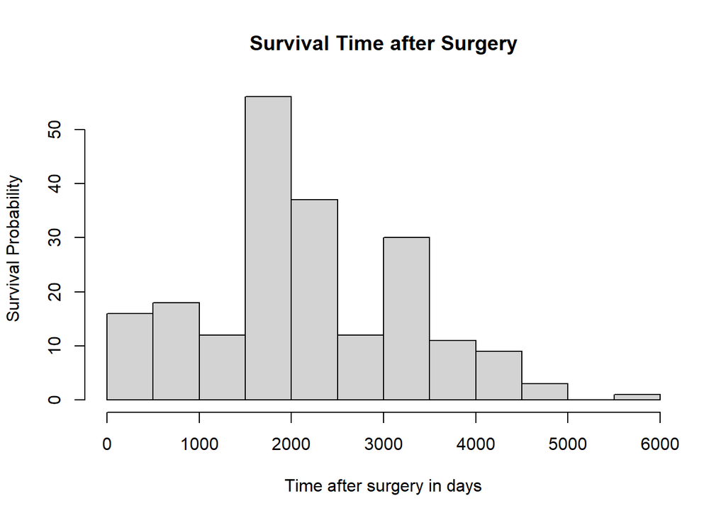

```r
#Visualise of time distribution
hist(melanoma_2$time, main = "Survival Time after Surgery", xlab = "Time after surgery in days", ylab = "Survival Probability")
```

The above histogram of the `Time` variable visualizes the distribution of survival times among patients. The x-axis represents the survival time in days, and the y-axis represents the frequency of patients with that survival time. The histogram easily identifies a good proportion of patients lived for about 1500 to 2500 days after surgery.

### 2.3 Status

```
   Min. 1st Qu.  Median    Mean 3rd Qu.    Max.
   1.00    1.00    2.00    1.79    2.00    3.00
```

```
[1] 0.5512041
```

```
[1] 0.3038259
```

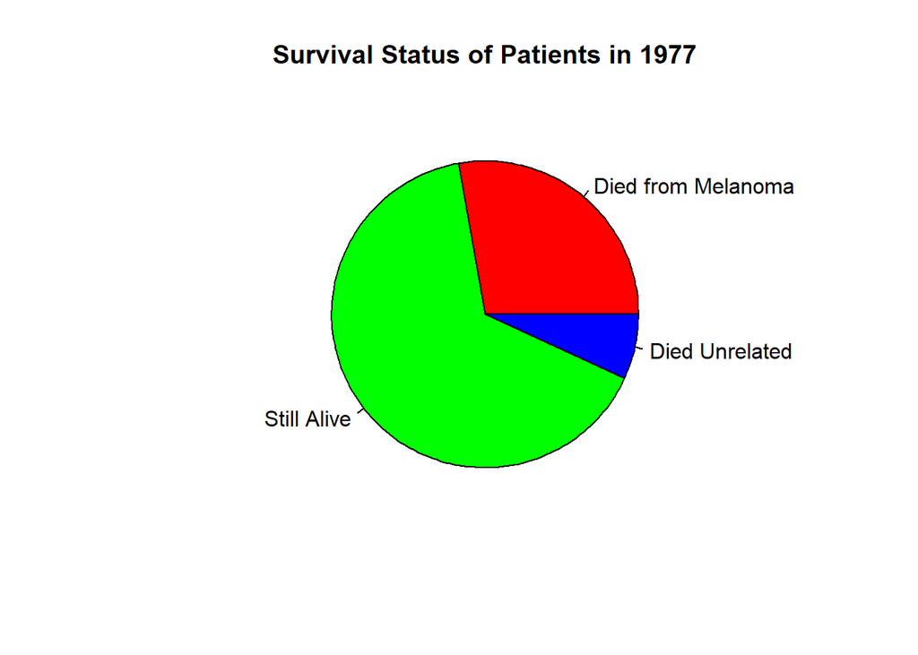

```r
#Visualise Status distribution
#hist(melanoma_2$status, main = "Survival Status of Patient in 1977 ", xlab = "Survival Status")

status_counts <- table(melanoma_2$status)
# Create a color palette for the pie chart
colors <- c("red", "green", "blue")
# Create the pie chart
pie(status_counts, labels = c("Died from Melanoma", "Still Alive", "Died Unrelated"), col = colors, main = "Survival Status of Patients in 1977")
```

### 2.4 Sex

```r
 #| echo: false

 # Sex Data Five Number Summary
 summary(melanoma_2$sex)
```

```
   Min. 1st Qu.  Median    Mean 3rd Qu.    Max.
 0.0000  0.0000  0.0000  0.3854  1.0000  1.0000
```

```r
 # Standard Deviation
 sd(melanoma_2$sex)
```

```
[1] 0.487873
```

```r
 # Variance
 var(melanoma_2$sex)
```

```
[1] 0.2380201
```

The `Sex` variable has a mean of 0.3854, indicating that the majority of patients were female

A barplot of the `Sex` variable visualizes the proportion of male and female patients in the data set. A significant observation of the gender distribution indicates melanoma is more common in females than in males. As observed we surgery was performed on 79 males compared to almost double the figures of female patients at 126

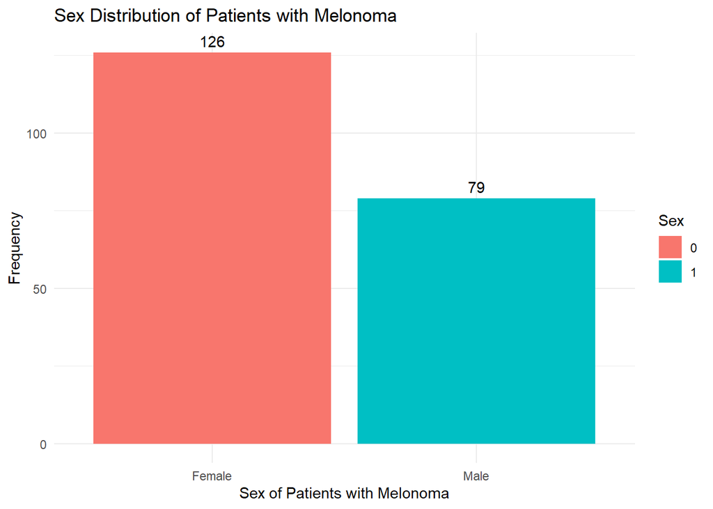

```r
ggplot(melanoma_2, aes(x = factor(sex), fill = factor(sex))) + geom_bar() + labs(title = "Sex Distribution of Patients with Melonoma", x = "Sex of Patients with Melonoma", y = "Frequency", fill = "Sex") + scale_x_discrete(labels = c("Female", "Male")) + geom_text(stat = "count", aes(label = stat(count)), vjust = -0.5) + theme_minimal()
```

### 2.5 Age of Patient at Time of Operation

```r
  #| echo: false

# Age Data Five Number Summary
 summary(melanoma_2$age)
```

```
   Min. 1st Qu.  Median    Mean 3rd Qu.    Max.
   4.00   42.00   54.00   52.46   65.00   95.00
```

```r
 # Standard Deviation
 sd(melanoma_2$age)
```

```
[1] 16.67171
```

```r
 # Variance
 var(melanoma_2$age)
```

```
[1] 277.946
```

The `Age` variable has a mean of 52.46 years and a standard deviation of 16.6 years, with a minimum age of 4 years and a maximum age of 95 years

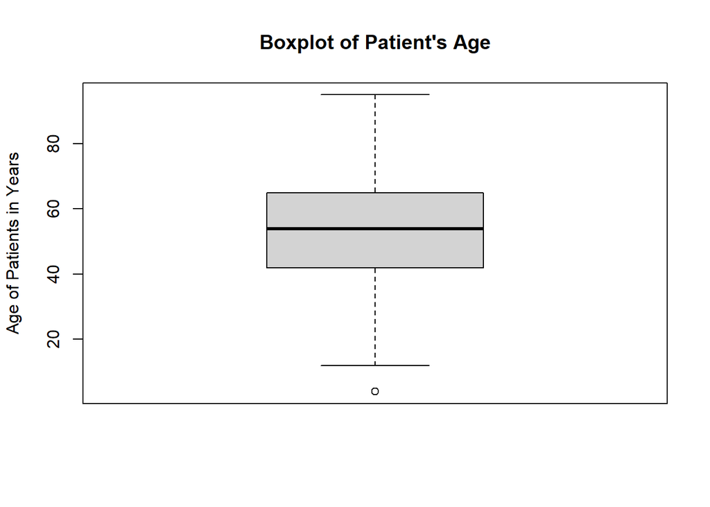

```r
boxplot(melanoma_2$age , main = "Boxplot of Patient's Age", ylab = "Age of Patients in Years")
```

The boxplot of the `Age` variable above visualizes an even distribution of ages among patients. An observation below the lower quartile is also recorded which indicates one of the patients was of considerable lower age than the rest of the patients.

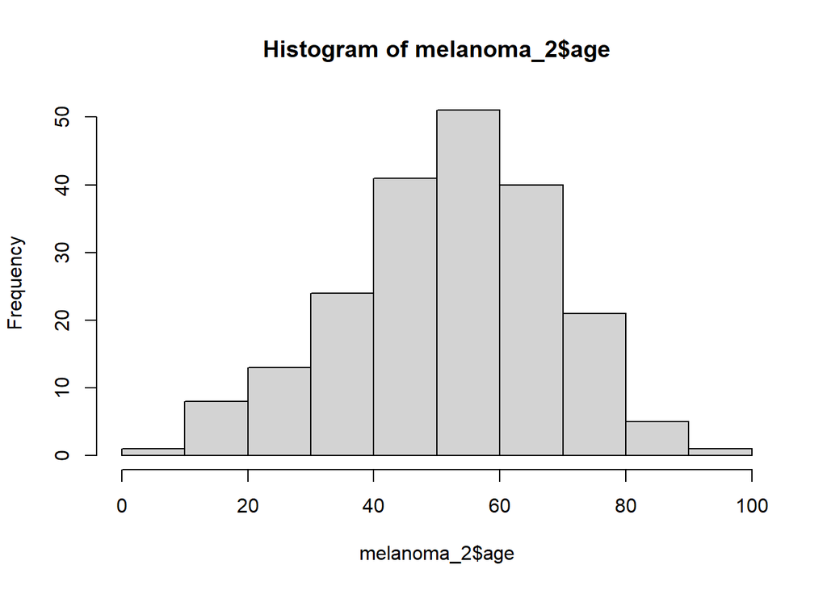

```r
hist(melanoma_2$age)
```

An histogram of the `Age` variable also helps observes the contraction of patients between the ages of 40 and 70.

### 2.6 Year of Operation

```
   Min. 1st Qu.  Median    Mean 3rd Qu.    Max.
   1962    1968    1970    1970    1972    1977
```

```
[1] 2.575563
```

```
[1] 6.633525
```

The `Year` variable has a mean of 1970 and a standard deviation of 2.57, with the earliest year being 1962 and the latest year being 1977

[figure not shown]

```r
#hist(melanoma_2$year, main = "Year of Surgery", xlab = "Year", ylab = "Frequency")
#boxplot(melanoma_2$year, main = "Year of Surgery", xlab = "Year", ylab = "Frequency")
ggplot(melanoma_2, aes(x = factor(year), fill = factor(year))) + geom_bar() + labs(title = "Distribution of Year of Surgery", x = "Year of Surgery", y = "Frequency", fill = "Year") + scale_x_discrete(labels = c("Year of Surgery")) + geom_text(stat = "count", aes(label = stat(count)), vjust = -0.5) + theme_minimal()
```

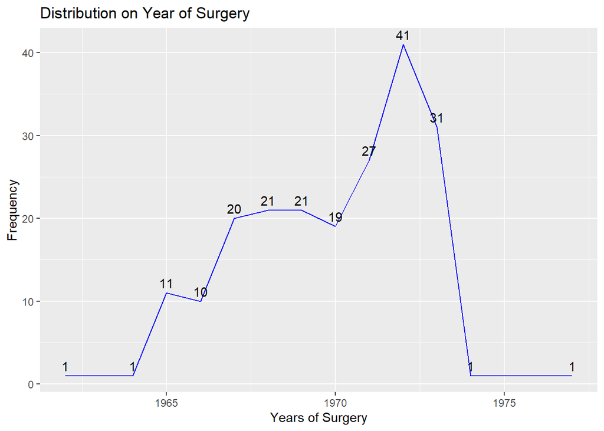

```r
 ggplot(melanoma_2, aes(x=year)) + geom_line(stat='count', color="blue") + labs(title="Distribution on Year of Surgery", x="Years of Surgery", y="Frequency") + geom_text(stat = "count", aes(label = stat(count)), vjust = -0.5)
```

### 2.7 Thickness of Tumor

```
   Min. 1st Qu.  Median    Mean 3rd Qu.    Max.
   0.10    0.97    1.94    2.92    3.56   17.42
```

```
[1] 2.959433
```

```
[1] 8.758242
```

The `Thickness` variable has a mean of 2.9 mm and a standard deviation of 2.95 mm, with a minimum thickness of 0.1 mm and a maximum thickness of 17.42 mm.

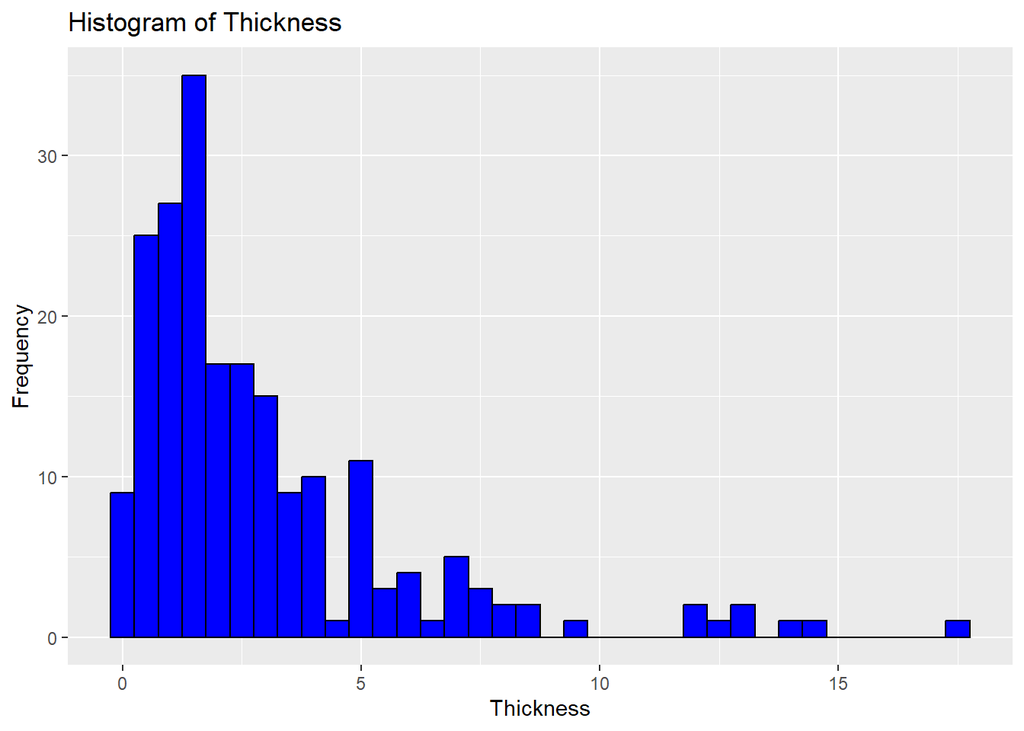

```r
ggplot(melanoma_2_, aes(x=thickness)) + geom_histogram(binwidth=0.5, fill="blue", color="black") + labs(title="Histogram of Thickness", x="Thickness", y="Frequency")
```

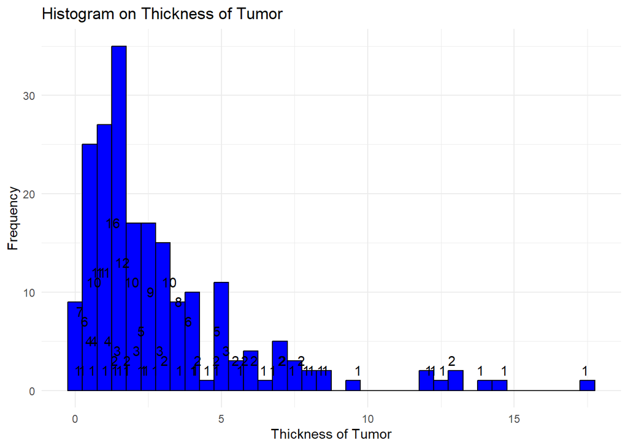

```r
ggplot(melanoma_2, aes(x=thickness)) + geom_histogram(binwidth=0.5, fill="blue", color="black") + labs(title="Histogram on Thickness of Tumor", x="Thickness of Tumor", y="Frequency", fill = "thickness") + geom_text(stat = "count", aes(label = stat(count)), vjust = -0.5) + theme_minimal()
```

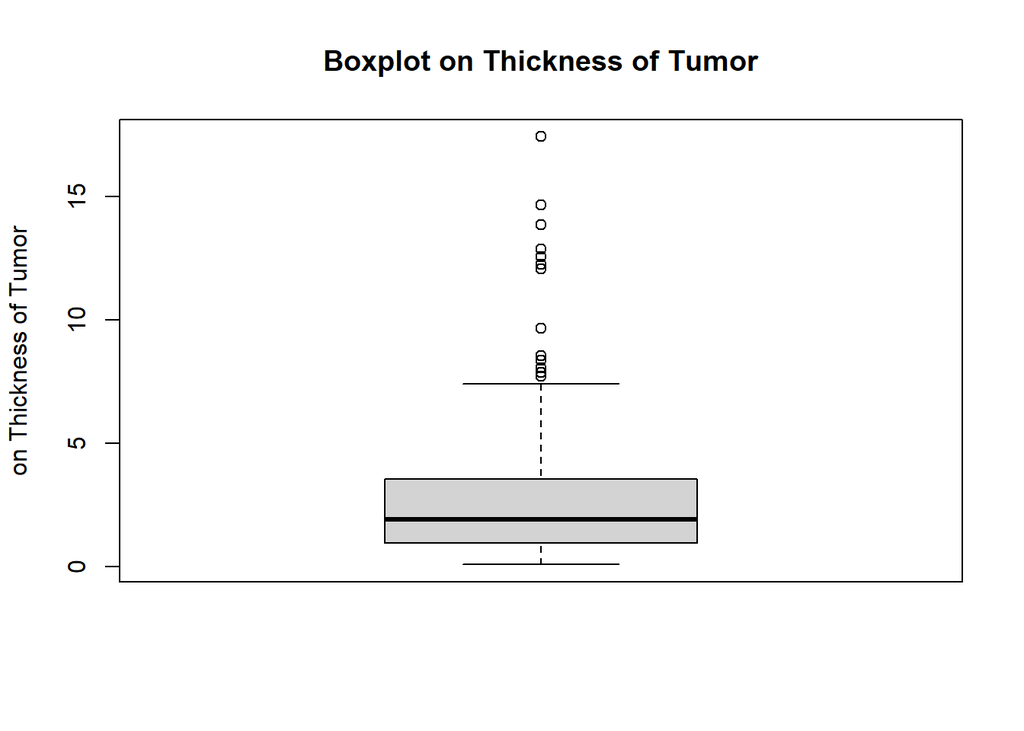

```r
boxplot(melanoma_2$thickness , main = "Boxplot on Thickness of Tumor", ylab = "on Thickness of Tumor")
```

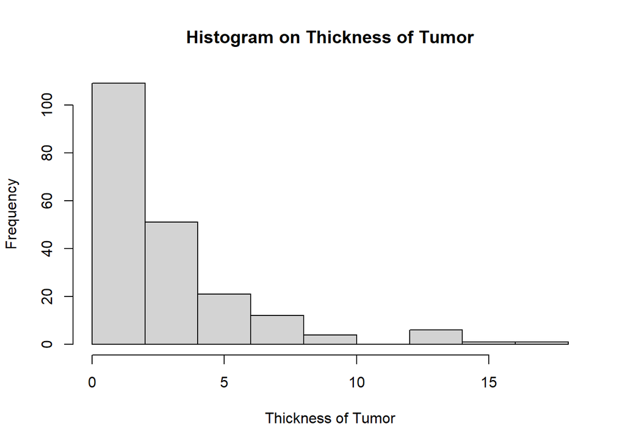

```r
hist(melanoma_2$thickness, main = "Histogram on Thickness of Tumor", xlab = "Thickness of Tumor", ylab = "Frequency")
```

[figure not shown]

```r
ggplot(melanoma_2, aes(x = factor(thickness), fill = factor(thickness))) + geom_bar() + labs(title = "Histogram on Thickness of Tumor", x = "Thickness of Tumor", y = "Frequency", fill = "thickness") + scale_x_discrete(labels = c("thickness", "thickness")) + geom_text(stat = "count", aes(label = stat(count)), vjust = -0.5) + theme_minimal()
```

### 2.8 Ulceration

```
   Min. 1st Qu.  Median    Mean 3rd Qu.    Max.
  0.000   0.000   0.000   0.439   1.000   1.000
```

```
[1] 0.4974829
```

```
[1] 0.2474892
```

The `Ulcer` variable has a mean of 0.44 , indicating that most patients did not have ulceration.

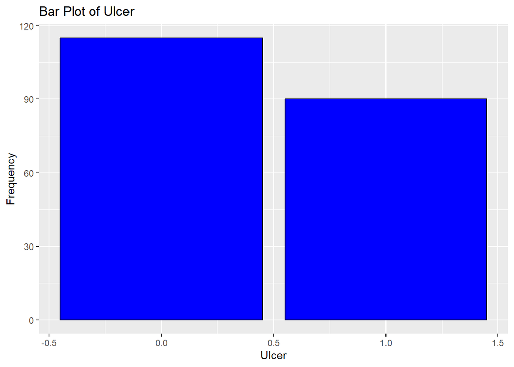

```r
ggplot(melanoma_2, aes(x=ulcer)) + geom_bar(fill="blue", color="black") +   labs(title="Bar Plot of Ulcer", x="Ulcer", y="Frequency")
```

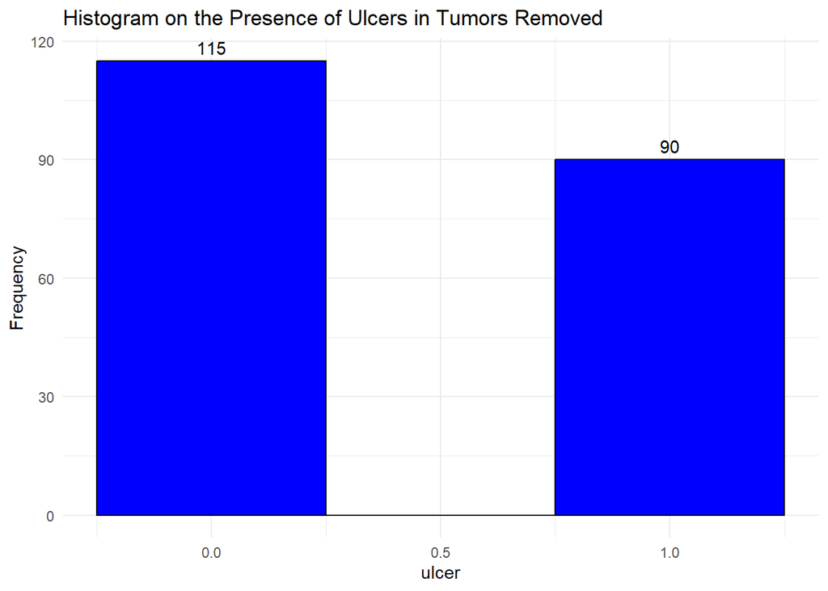

```r
ggplot(melanoma_2, aes(x=ulcer)) + geom_histogram(binwidth=0.5, fill="blue", color="black") + labs(title="Histogram on the Presence of Ulcers in Tumors Removed", x="ulcer", y="Frequency", fill = "ulcer") + geom_text(stat = "count", aes(label = stat(count)), vjust = -0.5) + theme_minimal()
```

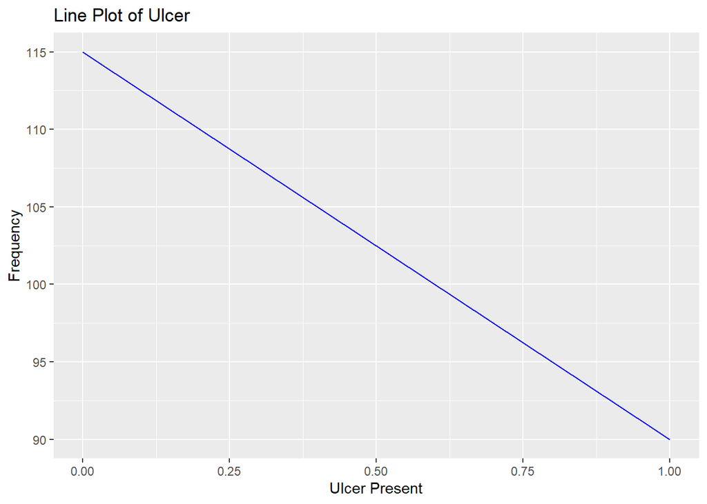

```r
ggplot(melanoma_2, aes(x=ulcer)) + geom_line(stat='count', color="blue") + labs(title="Line Plot of Ulcer", x="Ulcer Present", y="Frequency")
```

The line plot clearly shows that tumors removed from most patients were without ulceration.

## 3 Correlation and Regression Analysis

### 3.1 Time and Thickness

In this section we want to find out if a linear relationship exists between Age, thickness, and time variables,how strong are those relationships and what the relationships are if they exist

```r
TT_model <- lm(time ~ thickness, melanoma_2)
summary(TT_model)
```

```
Call:
lm(formula = time ~ thickness, data = melanoma_2)

Residuals:
    Min      1Q  Median      3Q     Max
-2325.4  -707.6  -210.6   744.9  3410.4

Coefficients:
            Estimate Std. Error t value Pr(>|t|)
(Intercept)  2413.41     107.39  22.473  < 2e-16 ***
thickness     -89.25      25.86  -3.451 0.000679 ***
---
Signif. codes:  0 '***' 0.001 '**' 0.01 '*' 0.05 '.' 0.1 ' ' 1

Residual standard error: 1093 on 203 degrees of freedom
Multiple R-squared:  0.05542,   Adjusted R-squared:  0.05076
F-statistic: 11.91 on 1 and 203 DF,  p-value: 0.0006793
```

```r
TT_model = lm(formula = melanoma_2$time ~ melanoma_2$thickness)
TT_model
```

```
Call:
lm(formula = melanoma_2$time ~ melanoma_2$thickness)

Coefficients:
         (Intercept)  melanoma_2$thickness
             2413.41                -89.25
```

```r
summary(TT_model)
```

```
Call:
lm(formula = melanoma_2$time ~ melanoma_2$thickness)

Residuals:
    Min      1Q  Median      3Q     Max
-2325.4  -707.6  -210.6   744.9  3410.4

Coefficients:
                     Estimate Std. Error t value Pr(>|t|)
(Intercept)           2413.41     107.39  22.473  < 2e-16 ***
melanoma_2$thickness   -89.25      25.86  -3.451 0.000679 ***
---
Signif. codes:  0 '***' 0.001 '**' 0.01 '*' 0.05 '.' 0.1 ' ' 1

Residual standard error: 1093 on 203 degrees of freedom
Multiple R-squared:  0.05542,   Adjusted R-squared:  0.05076
F-statistic: 11.91 on 1 and 203 DF,  p-value: 0.0006793
```

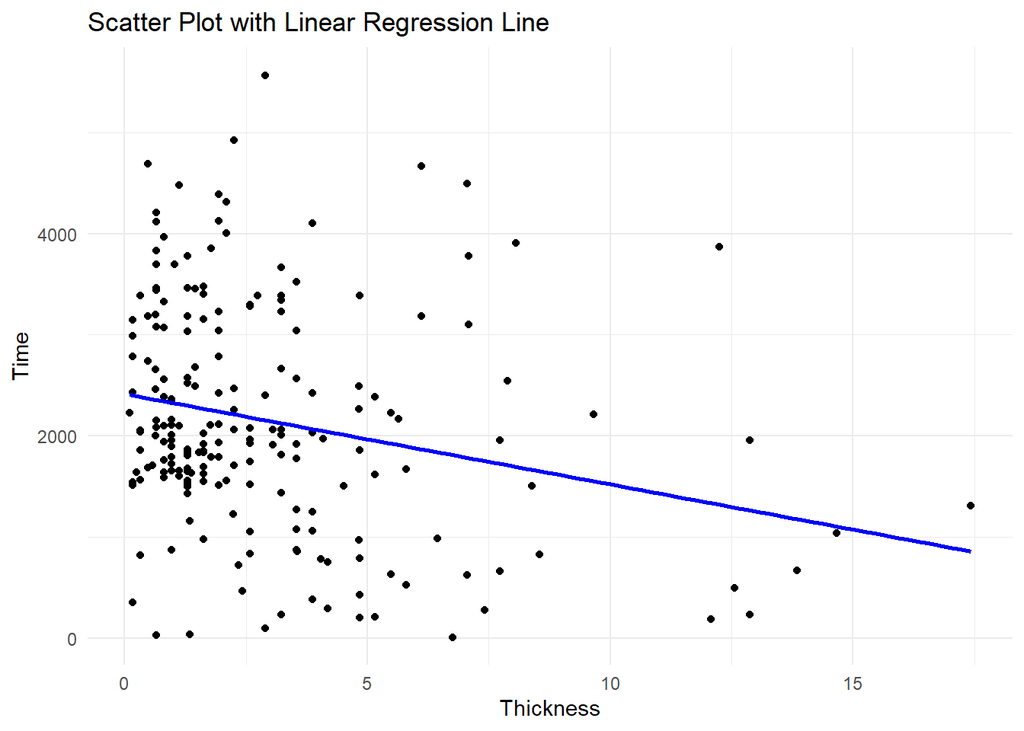

```r
ggplot(melanoma_2, aes(x = thickness, y = time)) + geom_point() + geom_smooth(method = "lm", se = FALSE, color = "blue") + labs(title = "Scatter Plot with Linear Regression Line",x = "Thickness", y = "Time") + theme_minimal()
```

```r
#plot(melanoma_2$time, melanoma_2$thickness, melanoma_2_)
cor(melanoma_2$time, melanoma_2$thickness)
```

```
[1] -0.2354087
```

```r
LinRegTT <- lm(formula = melanoma_2$time ~ melanoma_2$thickness)
LinRegTT
```

```
Call:
lm(formula = melanoma_2$time ~ melanoma_2$thickness)

Coefficients:
         (Intercept)  melanoma_2$thickness
             2413.41                -89.25
```

```r
summary(LinRegTT)
```

```
Call:
lm(formula = melanoma_2$time ~ melanoma_2$thickness)

Residuals:
    Min      1Q  Median      3Q     Max
-2325.4  -707.6  -210.6   744.9  3410.4

Coefficients:
                     Estimate Std. Error t value Pr(>|t|)
(Intercept)           2413.41     107.39  22.473  < 2e-16 ***
melanoma_2$thickness   -89.25      25.86  -3.451 0.000679 ***
---
Signif. codes:  0 '***' 0.001 '**' 0.01 '*' 0.05 '.' 0.1 ' ' 1

Residual standard error: 1093 on 203 degrees of freedom
Multiple R-squared:  0.05542,   Adjusted R-squared:  0.05076
F-statistic: 11.91 on 1 and 203 DF,  p-value: 0.0006793
```

### 3.2 Time and Age

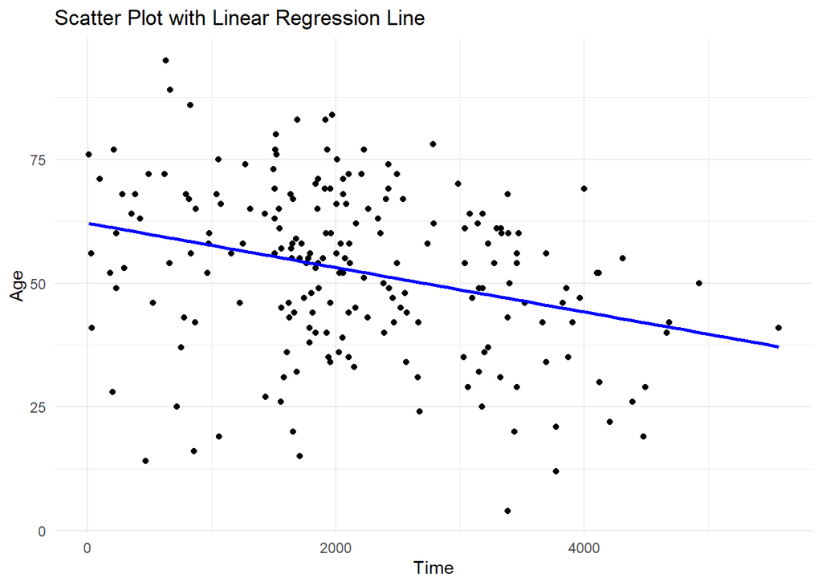

```r
ggplot(melanoma_2, aes(x = time, y = age)) + geom_point() + geom_smooth(method = "lm", se = FALSE, color = "blue") + labs(title = "Scatter Plot with Linear Regression Line",x = "Time", y = "Age") + theme_minimal()
```

```r
cor(melanoma_2$time, melanoma_2$age)
```

```
[1] -0.3015179
```

```r
LinRegTA <- lm(formula = melanoma_2$time ~ melanoma_2$age)
LinRegTA
```

```
Call:
lm(formula = melanoma_2$time ~ melanoma_2$age)

Coefficients:
   (Intercept)  melanoma_2$age
       3217.45          -20.29
```

```r
summary(LinRegTA)
```

```
Call:
lm(formula = melanoma_2$time ~ melanoma_2$age)

Residuals:
    Min      1Q  Median      3Q     Max
-2464.3  -646.2   -54.4   712.1  3179.6

Coefficients:
               Estimate Std. Error t value Pr(>|t|)
(Intercept)    3217.448    247.879  12.980  < 2e-16 ***
melanoma_2$age  -20.293      4.504  -4.506 1.12e-05 ***
---
Signif. codes:  0 '***' 0.001 '**' 0.01 '*' 0.05 '.' 0.1 ' ' 1

Residual standard error: 1072 on 203 degrees of freedom
Multiple R-squared:  0.09091,   Adjusted R-squared:  0.08643
F-statistic:  20.3 on 1 and 203 DF,  p-value: 1.116e-05
```

### 3.3 Thickness and Age

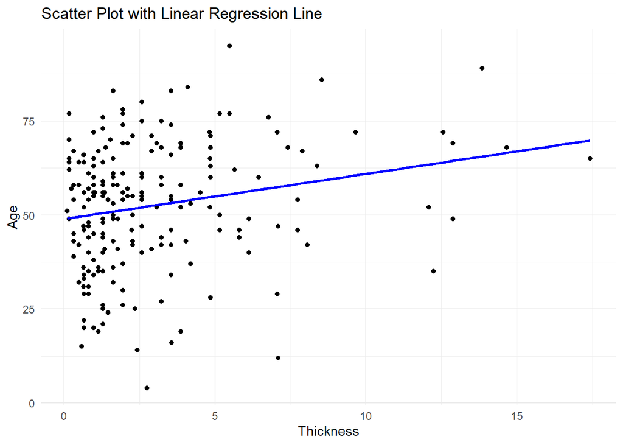

```r
ggplot(melanoma_2, aes(x = thickness, y = age)) + geom_point() + geom_smooth(method = "lm", se = FALSE, color = "blue") + labs(title = "Scatter Plot with Linear Regression Line",x = "Thickness", y = "Age") + theme_minimal()
```

```r
cor(melanoma_2$thickness, melanoma_2$age)
```

```
[1] 0.2124798
```

```r
LinRegTHA <- lm(formula = melanoma_2$thickness ~ melanoma_2 $age)
LinRegTHA
```

```
Call:
lm(formula = melanoma_2$thickness ~ melanoma_2$age)

Coefficients:
   (Intercept)  melanoma_2$age
       0.94105         0.03772
```